# Using brolgar to understand Mixed Effects Models

```r
library(brolgar)
library(lme4)
library(modelr)
library(ggplot2)
```

Just as it is important to explore your data before modelling, it is important to explore your data after you fit a model, and during the modelling process.

Let’s take our wages data

```r
wages
```

```
#> # A tsibble: 6,402 x 9 [!]
#> # Key:       id [888]
#>       id ln_wages    xp   ged xp_since_ged black hispanic high_grade
#>    <int>    <dbl> <dbl> <int>        <dbl> <int>    <int>      <int>
#>  1    31     1.49 0.015     1        0.015     0        1          8
#>  2    31     1.43 0.715     1        0.715     0        1          8
#>  3    31     1.47 1.73      1        1.73      0        1          8
#>  4    31     1.75 2.77      1        2.77      0        1          8
#>  5    31     1.93 3.93      1        3.93      0        1          8
#>  6    31     1.71 4.95      1        4.95      0        1          8
#>  7    31     2.09 5.96      1        5.96      0        1          8
#>  8    31     2.13 6.98      1        6.98      0        1          8
#>  9    36     1.98 0.315     1        0.315     0        0          9
#> 10    36     1.80 0.983     1        0.983     0        0          9
#> # ℹ 6,392 more rows
#> # ℹ 1 more variable: unemploy_rate <dbl>
```

We might explore this by looking at experience against wages, for each individual:

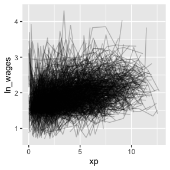

```r
gg_wages_all <-
ggplot(wages,
       aes(x = xp,
           y = ln_wages,
           group = id)) +
  geom_line(alpha = 0.25)

gg_wages_all
```

But - Ugh. Spaghetti plot.

Let’s look at a random sample of people using `facet_sample()`

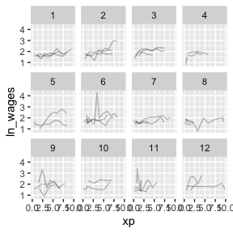

```r
gg_wages_all +
  facet_sample()
```

Now let’s look at all of the data, arranging by `unemploy_rate`:

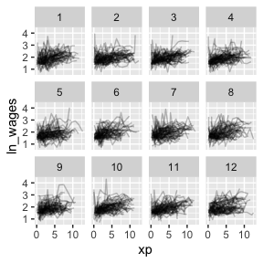

```r
gg_wages_all + facet_strata()
```

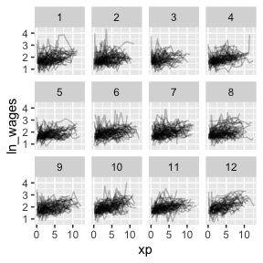

```r
gg_wages_all +
  facet_strata(along = unemploy_rate)
```

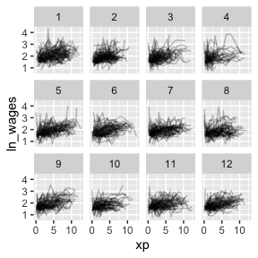

```r
gg_wages_all +
  facet_strata(along = xp_since_ged)
```

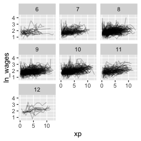

```r
gg_wages_all + facet_wrap(~high_grade)
```

```r
library(lme4)
wages_fit_int <- lmer(ln_wages ~ xp + ged + unemploy_rate + (xp |id),
                      data = wages)
```

We can use the tools from `modelr` to add predictions and residuals to the data

```r
library(modelr)
wages_aug <- wages %>%
  add_predictions(wages_fit_int, var = "pred_int") %>%
  add_residuals(wages_fit_int, var = "res_int")
```

Now let’s look at the predictions over xp

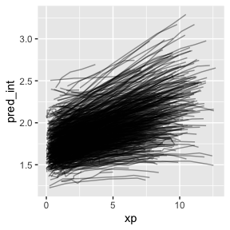

```r
ggplot(wages_aug,
       aes(x = xp,
           y = pred_int,
           group = id)) +
  geom_line(alpha = 0.4)
```

Ugh. Straight spaghetti. Let’s sample that.

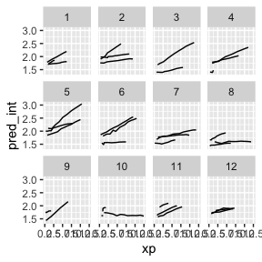

```r
ggplot(wages_aug,
       aes(x = xp,
           y = pred_int,
           group = id)) +
  geom_line() +
  facet_sample()
```

And let’s explore these according to residuals.

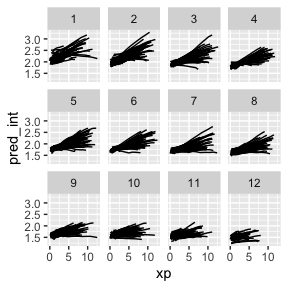

```r
ggplot(wages_aug,
       aes(x = xp,
           y = pred_int,
           group = id)) +
  geom_line() +
  facet_strata(along = res_int)
```

Now let’s add in the data to the predictions.

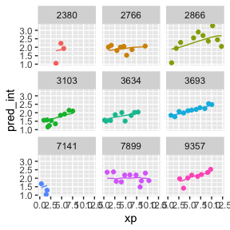

```r
wages_aug %>%
  sample_n_keys(size = 9) %>%
  ggplot(aes(x = xp,
             y = pred_int,
             group = id,
             colour = factor(id))) +
  geom_line() +
  geom_point(aes(x = xp,
                 y = ln_wages,
                 colour = factor(id))) +
  facet_wrap(~id) +
  theme(legend.position = "none")
```

What if we grabbed a sample of those who have the best, middle, and worst residuals? Those who are closest to these values:

```r
summary(wages_aug$res_int)
```

```
#>      Min.   1st Qu.    Median      Mean   3rd Qu.      Max.
#> -1.305694 -0.159728 -0.009445  0.000000  0.136411  2.148938
```

We can use `keys_near()` to return those specified keys that are close to these values. Because this is a `tsibble` object, we don’t need to specify the `key` variable here.

```r
wages_aug_near <- wages_aug %>%
  keys_near(var = res_int)

wages_aug_near
```

```
#> # A tibble: 6 × 5
#>      id  res_int stat  stat_value  stat_diff
#>   <int>    <dbl> <fct>      <dbl>      <dbl>
#> 1   122 -1.31    min     -1.31    0
#> 2   735  2.15    max      2.15    0
#> 3  2026 -0.00956 med     -0.00945 0.000115
#> 4  3961 -0.00933 med     -0.00945 0.000115
#> 5  5778 -0.160   q_25    -0.160   0.0000113
#> 6  8246  0.136   q_75     0.136   0.00000363
```

This shows us the keys where we the residuals match closest to the five number summary.

We can plot this data by joining it back to the wages data with predictions, to see what the spread of predictions is like.

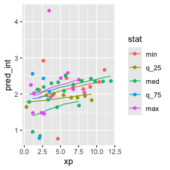

```r
library(dplyr)

wages_aug_near_full <- left_join(wages_aug_near,
                                 wages_aug,
                                 by = "id")

gg_wages_near <-
  ggplot(wages_aug_near_full,
       aes(x = xp,
           y = pred_int,
           group = id,
           colour = stat)) +
  geom_line() +
  geom_point(aes(y = ln_wages))

gg_wages_near
```

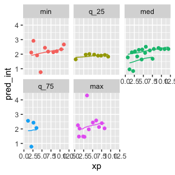

```r
gg_wages_near +
 facet_wrap(~stat) +
  theme(legend.position = "none")
```

We can also use `stratify_along` to group by the worst fits

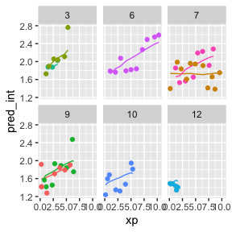

```r
wages_aug %>%
  stratify_keys(n_strata = 12,
                along = res_int) %>%
  sample_n_keys(size = 9) %>%
  ggplot(aes(x = xp,
             y = pred_int,
             group = id,
             colour = factor(id))) +
  geom_line() +
  geom_point(aes(x = xp,
                 y = ln_wages,
                 colour = factor(id))) +
  facet_wrap(~.strata) +
  theme(legend.position = "none")
```